# Analysis of World Economic Factors

Benjamin Barnett

5/7/2021

In this project, we study the population density, population growth rate, life expectancy at birth, real GDP per capita, unemployment rate, and Gini index coefficient of more than 200 countries to better understand living conditions around the world. We also aggregate the countries by continent to analyze common trends and evaluate factors associated with life expectancy at birth. Our data set takes population density from Worldometers and the remaining features from CIA World Factbook.

After we load the required packages, we store the country and continent data from the choroplethrMaps library for later use.

```r
data(country.map)
choropleth <- unique(country.map$region)
choropleth <- choropleth[order(choropleth)]
head(choropleth)
```

```
## [1] "afghanistan" "albania"     "algeria"     "angola"      "antarctica"
## [6] "argentina"
```

```r
ref <- unique(data.table(country.map$region, country.map$continent))
ref <- data.frame(ref[,1], ref[,2]); colnames(ref) <- c("region", "continent")
head(ref)
```

```
##        region     continent
## 1 afghanistan          Asia
## 2      angola        Africa
## 3  azerbaijan          Asia
## 4     moldova        Europe
## 5  madagascar        Africa
## 6      mexico North America
```

By plotting world heat maps for each feature, we can acquire great insight in overall living conditions. However, the scrapped and choroplethrMaps data each have different lists of countries. To solve this, we use the miss_overlap function, where missing_list returns the countries exclusive to the scraped data and overlap_list returns the countries exclusive to the choroplethrMaps data.

```r
miss_overlap <- function(country_list){
missing_list <- NULL; match_list <- NULL
for(i in seq(length(country_list))){
    tick <- 0
    for(j in seq(length(choropleth))){
        if(country_list[i] == choropleth[j]){
            match_list <- c(match_list, country_list[i])
            break
            }
        tick <- tick + 1
        if(tick == length(choropleth)){
            missing_list <- c(missing_list, country_list[i])
            }
        }
    }
overlap_list <- NULL
for(i in seq(length(choropleth))){
    tick <- 0
    for(j in seq(length(match_list))){
        if(choropleth[i] != match_list[j]){
            tick <- tick + 1
            }
        if(tick == length(match_list)){
            overlap_list <- c(overlap_list, choropleth[i])
            }
        }
    }
list(missing_list=missing_list, overlap_list=overlap_list)
}
```

After scraping the population density data and tidying it, we run the miss_overlap function to find the country strings in the scraped data that need to be replaced to match the alternative country names in the choroplethrMaps data.

```r
url_1 <- "https://www.worldometers.info/world-population/population-by-country/"
pop_density_tables <- url_1 %>% read_html() %>% html_nodes("table") %>% html_table()
pop_density <- data.frame(pop_density_tables[[1]][2], pop_density_tables[[1]][6])

colnames(pop_density) <- c("region", "value")
pop_density[,1] <- tolower(pop_density[,1])
pop_density[,2] <- as.numeric(gsub(",", "", pop_density[,2]))
pop_density <- pop_density[order(pop_density),]
pop_density <- na.omit(pop_density)

miss_overlap(pop_density[,1])
```

```
## $missing_list
##  [1] "american samoa"           "andorra"
##  [3] "anguilla"                 "antigua and barbuda"
##  [5] "aruba"                    "bahamas"
##  [7] "bahrain"                  "barbados"
##  [9] "bermuda"                  "british virgin islands"
## [11] "cabo verde"               "caribbean netherlands"
## [13] "cayman islands"           "channel islands"
## [15] "comoros"                  "congo"
## [17] "cook islands"             "côte d'ivoire"
## [19] "curaçao"                  "czech republic (czechia)"
## [21] "dominica"                 "dr congo"
## [23] "eswatini"                 "faeroe islands"
## [25] "falkland islands"         "french guiana"
## [27] "french polynesia"         "gibraltar"
```

[output cut: 36 more lines]

Many countries are exclusive to the scraped data, but not that many countries are exclusive to the choroplethrMaps data. Because the world heat map only plots countries from the choroplethrMaps data, we use the miss_overlap output as a reference to check for alternative country names in the scraped data. Below are all of the countries from the scraped data sorted in alphabetical order.

```r
print(pop_density[,1])
```

```
##   [1] "afghanistan"              "albania"
##   [3] "algeria"                  "american samoa"
##   [5] "andorra"                  "angola"
##   [7] "anguilla"                 "antigua and barbuda"
##   [9] "argentina"                "armenia"
##  [11] "aruba"                    "australia"
##  [13] "austria"                  "azerbaijan"
##  [15] "bahamas"                  "bahrain"
##  [17] "bangladesh"               "barbados"
##  [19] "belarus"                  "belgium"
##  [21] "belize"                   "benin"
##  [23] "bermuda"                  "bhutan"
##  [25] "bolivia"                  "bosnia and herzegovina"
##  [27] "botswana"                 "brazil"
##  [29] "british virgin islands"   "brunei"
```

[output cut: 103 more lines]

Using overlap_list as a guide, we replace the country strings below and plot our map.

```r
pop_density[15,1] <- "the bahamas"
pop_density[47,1] <- "republic of congo"
pop_density[50,1] <- "ivory coast"
pop_density[55,1] <- "czech republic"
pop_density[60,1] <- "democratic republic of the congo"
pop_density[67,1] <- "swaziland"
pop_density[89,1] <- "guinea bissau"
pop_density[155,1] <- "macedonia"
pop_density[185,1] <- "republic of serbia"
pop_density[208,1] <- "united republic of tanzania"
pop_density[210,1] <- "east timor"
pop_density[225,1] <- "united states of america"
```

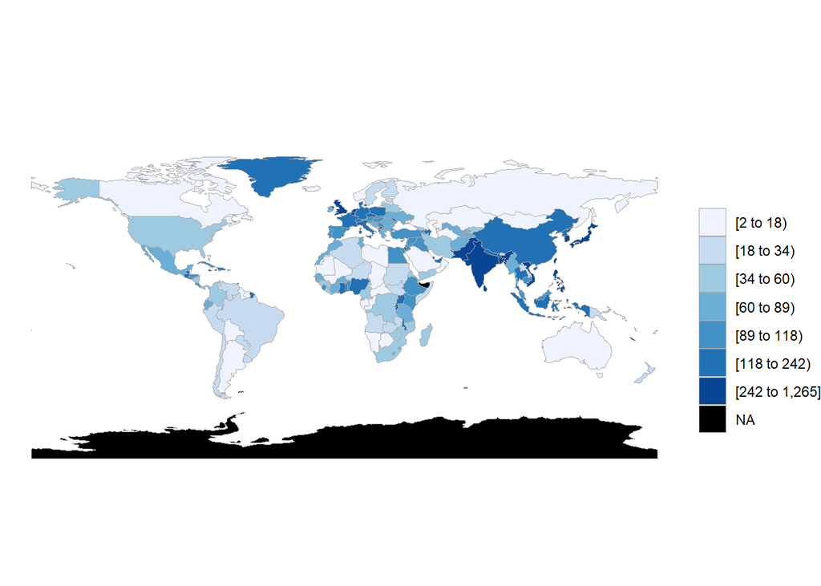

The map above shows population density in P/ Km^2. We can see that many Eastern countries, including India, Pakistan, Vietnam, Japan, and the Philippines have high population densities relative to other parts of the world. Interestingly, the United Kingdom is also dense, which is likely due to its good soil and mild climate. On the other extreme, Canada, Argentina, Bolivia, Australia, Saudia Arabia, Russia, and Mongolia notably have very low population densities.

Using the dataframe ref to tidy the data by continent. The single country beloning to “Seven seas (open ocean)” was removed for visual purposes.

```r
pop_density_continent <- merge(pop_density, ref)[,-1]

index_remove <- NULL
for(i in seq(nrow(pop_density_continent))){
    if(pop_density_continent[i,2] == "Seven seas (open ocean)"){
        index_remove <- c(index_remove, i)
        }
    }

pop_density_continent <- as_tibble(pop_density_continent[-index_remove,])
```

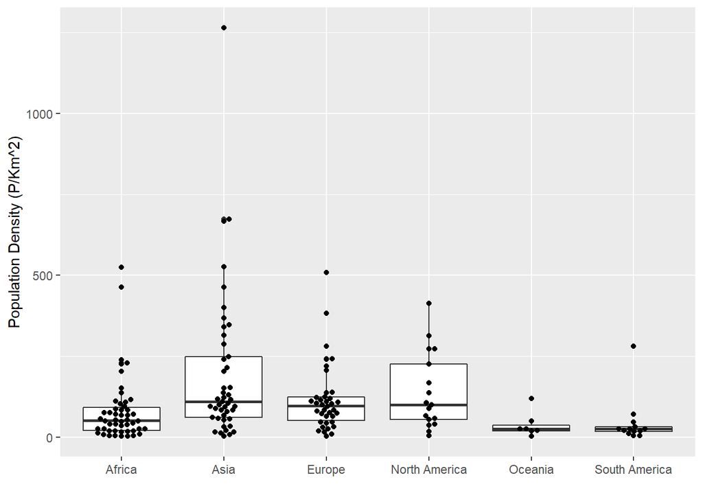

We can see that Africa, Oceania, and South America have lower population densities, while parts of Asia and Europe are more densely populated.

```r
head(pop_density[order(pop_density[,2], decreasing=TRUE),])
```

```
##        region value
## 214    monaco 26337
## 167     macao 21645
## 114 singapore  8358
## 104 hong kong  7140
## 219 gibraltar  3369
## 152   bahrain  2239
```

```r
tail(pop_density[order(pop_density[,2], decreasing=TRUE),])
```

```
##               region value
## 181          iceland     3
## 143          namibia     3
## 136         mongolia     2
## 170   western sahara     2
## 232 falkland islands     0
## 209        greenland     0
```

Interestingly, population densities range anywhere from over 20,000 people per km squared to less than 1 person per km squared. Monaco is the most populated country in the world, and Greenland is the least. (For clarification, the choropleth map shows the density of Denmark as a whole.)

Using the same process as before, we scrap population growth data and tidy it to plot on choropleth map.

```r
url_2 <- "https://www.cia.gov/the-world-factbook/field/population-growth-rate/country-comparison"
pop_growth_tables <- url_2 %>% read_html() %>% html_nodes("table") %>% html_table()
pop_growth <- data.frame(pop_growth_tables[[1]][2], pop_growth_tables[[1]][3])

colnames(pop_growth) <- c("region", "value")
pop_growth[,1] <- tolower(pop_growth[,1])
pop_growth <- pop_growth[order(pop_growth),]
pop_growth <- na.omit(pop_growth)

pop_growth[16,1] <- "the bahamas"
pop_growth[34,1] <- "myanmar"
pop_growth[48,1] <- "democratic republic of the congo"
pop_growth[49,1] <- "republic of congo"
pop_growth[52,1] <- "ivory coast"
pop_growth[57,1] <- "czech republic"
pop_growth[68,1] <- "swaziland"
pop_growth[77,1] <- "gambia"
pop_growth[90,1] <- "guinea bissau"
pop_growth[113,1] <- "north korea"
pop_growth[114,1] <- "south korea"
pop_growth[188,1] <- "republic of serbia"
pop_growth[209,1] <- "united republic of tanzania"
pop_growth[211,1] <- "east timor"
pop_growth[225,1] <- "united states of america"
```

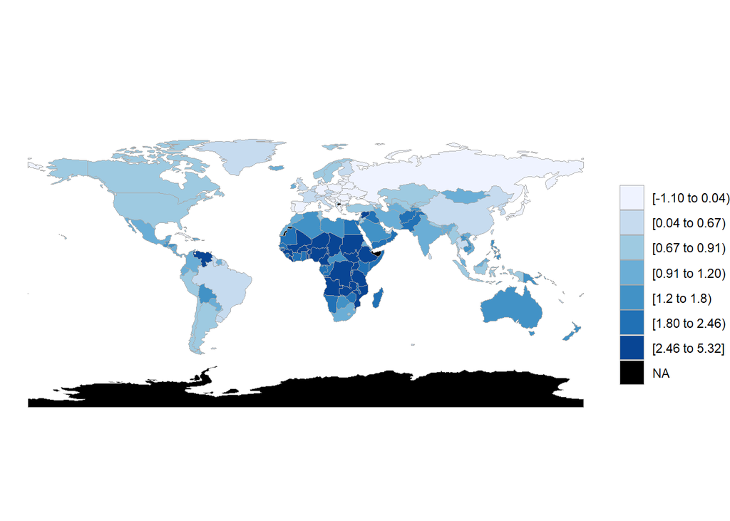

We see that much of the world population growth is from parts of Africa. While most regions are increasing in population, some parts of Europe are actually experience a population decrease.

Using the dataframe ref to tidy the data by continent. The single country beloning to “Seven seas (open ocean)” was removed for visual purposes.

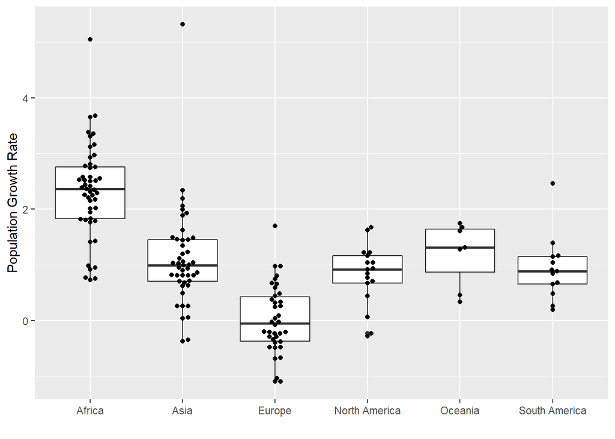

```r
pop_growth_continent <- merge(pop_growth, ref)[,-1]

index_remove <- NULL
for(i in seq(nrow(pop_growth_continent))){
    if(pop_growth_continent[i,2] == "Seven seas (open ocean)"){
        index_remove <- c(index_remove, i)
        }
    }

pop_growth_continent <- as_tibble(pop_growth_continent[-index_remove,])
pop_growth_continent %>% ggplot(aes(continent, value)) + labs(x="", y="Population Growth Rate") + geom_boxplot() + geom_beeswarm()
```

As expected, Africa has the highest population growth rates and Europe has the lowest. This implies that Africa’s currently low population densities are likely to change sometime in the near future.

```r
head(pop_growth[order(pop_growth[,2], decreasing=TRUE),])
```

```
##        region value
## 1       syria  5.32
## 2 south sudan  5.05
## 3     burundi  3.68
## 4       niger  3.65
## 5      angola  3.38
## 6       benin  3.36
```

```r
tail(pop_growth[order(pop_growth[,2], decreasing=TRUE),])
```

```
##                        region value
## 232                    latvia -1.10
## 231                   moldova -1.10
## 233 saint pierre and miquelon -1.20
## 234               puerto rico -1.46
## 235            american samoa -2.10
## 236              cook islands -2.46
```

Scraping life expectancy data and tidying it to plot on choropleth map.

```r
url_3 <- "https://www.cia.gov/the-world-factbook/field/life-expectancy-at-birth/country-comparison"
life_expectancy_tables <- url_3 %>% read_html() %>% html_nodes("table") %>% html_table()
life_expectancy <- data.frame(life_expectancy_tables[[1]][2], life_expectancy_tables[[1]][3])

colnames(life_expectancy) <- c("region", "value")
life_expectancy[,1] <- tolower(life_expectancy[,1])
life_expectancy <- life_expectancy[order(life_expectancy),]
life_expectancy <- na.omit(life_expectancy)

life_expectancy[15,1] <- "the bahamas"
life_expectancy[33,1] <- "myanmar"
life_expectancy[46,1] <- "democratic republic of the congo"
life_expectancy[47,1] <- "republic of congo"
life_expectancy[50,1] <- "ivory coast"
life_expectancy[55,1] <- "czech republic"
life_expectancy[66,1] <- "swaziland"
life_expectancy[74,1] <- "gambia"
life_expectancy[87,1] <- "guinea bissau"
life_expectancy[109,1] <- "north korea"
life_expectancy[110,1] <- "south korea"
life_expectancy[180,1] <- "republic of serbia"
life_expectancy[200,1] <- "united republic of tanzania"
life_expectancy[202,1] <- "east timor"
life_expectancy[215,1] <- "united states of america"
```

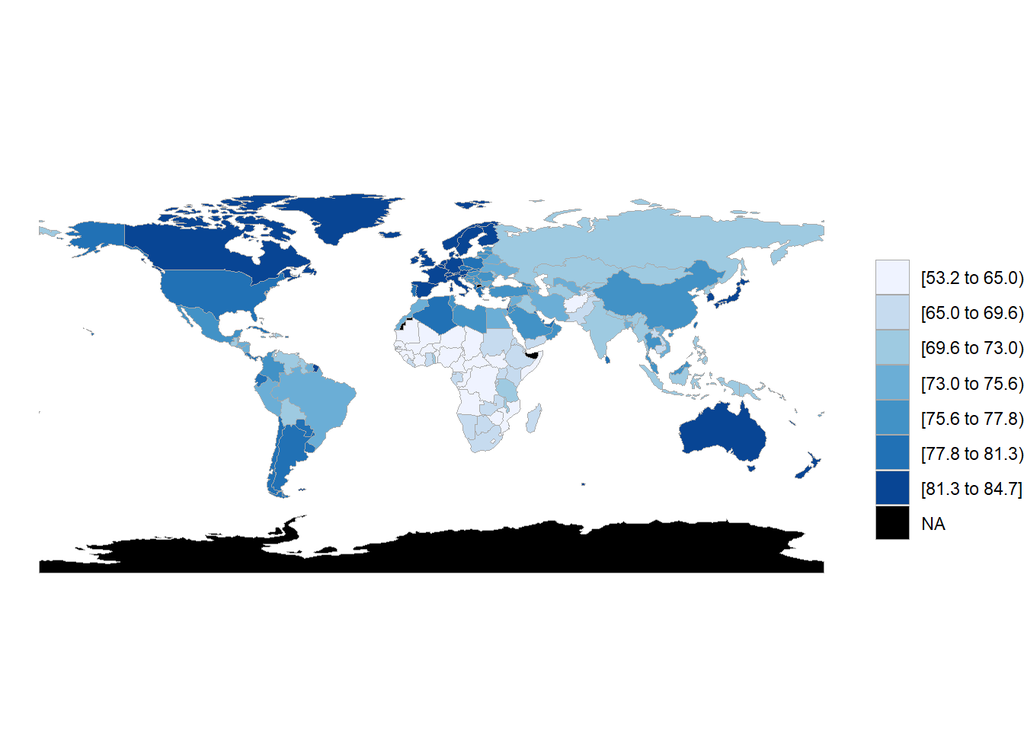

Unsurprisingly, Canada, Australia, Japan, and many parts of Europe have high life expectancies at birth. However, many parts of Africa have very low life expectancies at birth.

Using the dataframe ref to tidy the data by continent. The single country beloning to “Seven seas (open ocean)” was removed for visual purposes.

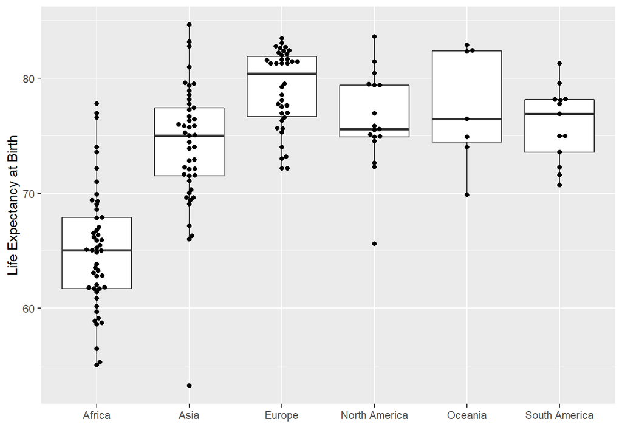

```r
life_expectancy_continent <- merge(life_expectancy, ref)[,-1]

index_remove <- NULL
for(i in seq(nrow(life_expectancy_continent))){
    if(life_expectancy_continent[i,2] == "Seven seas (open ocean)"){
        index_remove <- c(index_remove, i)
        }
    }

life_expectancy_continent <- as_tibble(life_expectancy_continent[-index_remove,])
life_expectancy_continent %>% ggplot(aes(continent, value)) + labs(x="", y="Life Expectancy at Birth") + geom_boxplot() + geom_beeswarm()
```

```r
head(life_expectancy[order(life_expectancy[,2], decreasing=TRUE),])
```

```
##       region value
## 1     monaco 89.40
## 2  singapore 86.19
## 3      macau 84.81
## 4      japan 84.65
## 5 san marino 83.68
## 6     canada 83.62
```

```r
tail(life_expectancy[order(life_expectancy[,2], decreasing=TRUE),])
```

```
##                       region value
## 221                     chad 58.73
## 222              south sudan 58.60
## 223               mozambique 56.49
## 224                  somalia 55.32
## 225 central african republic 55.07
## 226              afghanistan 53.25
```

Life expectancy at birth ranges anywhere from over 85 years to fewer than 60 years. Though Afghanistan has the lowest life expectancy at birth, the next bottom four countries are in Africa.

Scraping real GDP per capita and tidying it to plot on choropleth map.

```r
url_4 <- "https://www.cia.gov/the-world-factbook/field/real-gdp-per-capita/country-comparison"
real_gdp_tables <- url_4 %>% read_html() %>% html_nodes("table") %>% html_table()
real_gdp <- data.frame(real_gdp_tables[[1]][2], real_gdp_tables[[1]][3])

colnames(real_gdp) <- c("region", "value")
real_gdp[,1] <- tolower(real_gdp[,1])
real_gdp[,2] <- gsub("\\$", "", real_gdp[,2])
real_gdp[,2] <- as.numeric(gsub(",", "", real_gdp[,2]))
real_gdp <- real_gdp[order(real_gdp),]
real_gdp <- na.omit(real_gdp)

real_gdp[15,1] <- "the bahamas"
real_gdp[33,1] <- "myanmar"
real_gdp[46,1] <- "democratic republic of the congo"
real_gdp[47,1] <- "republic of congo"
real_gdp[50,1] <- "ivory coast"
real_gdp[55,1] <- "czech republic"
real_gdp[66,1] <- "swaziland"
real_gdp[75,1] <- "gambia"
real_gdp[88,1] <- "guinea bissau"
real_gdp[110,1] <- "north korea"
real_gdp[111,1] <- "south korea"
real_gdp[181,1] <- "republic of serbia"
real_gdp[200,1] <- "united republic of tanzania"
real_gdp[202,1] <- "east timor"
real_gdp[216,1] <- "united states of america"
```

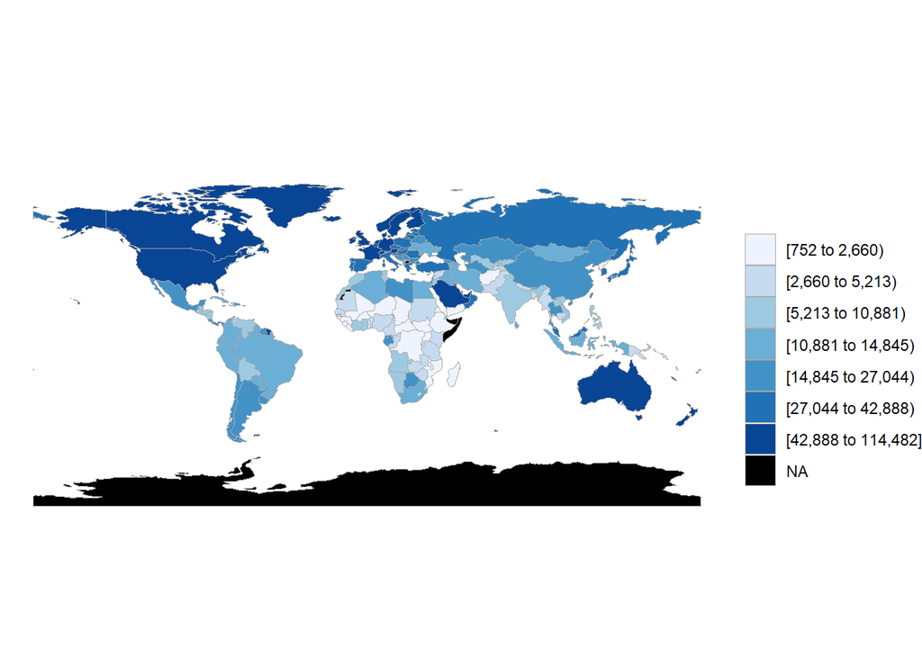

From the plot, we see that the United States, Canada, Australia, Saudi Arabia, and many parts of Europe have high GDP per capita. On the other hand, many parts of Africa have low GDP per capita.

Using the dataframe ref to tidy the data by continent. The single country beloning to “Seven seas (open ocean)” was removed for visual purposes.

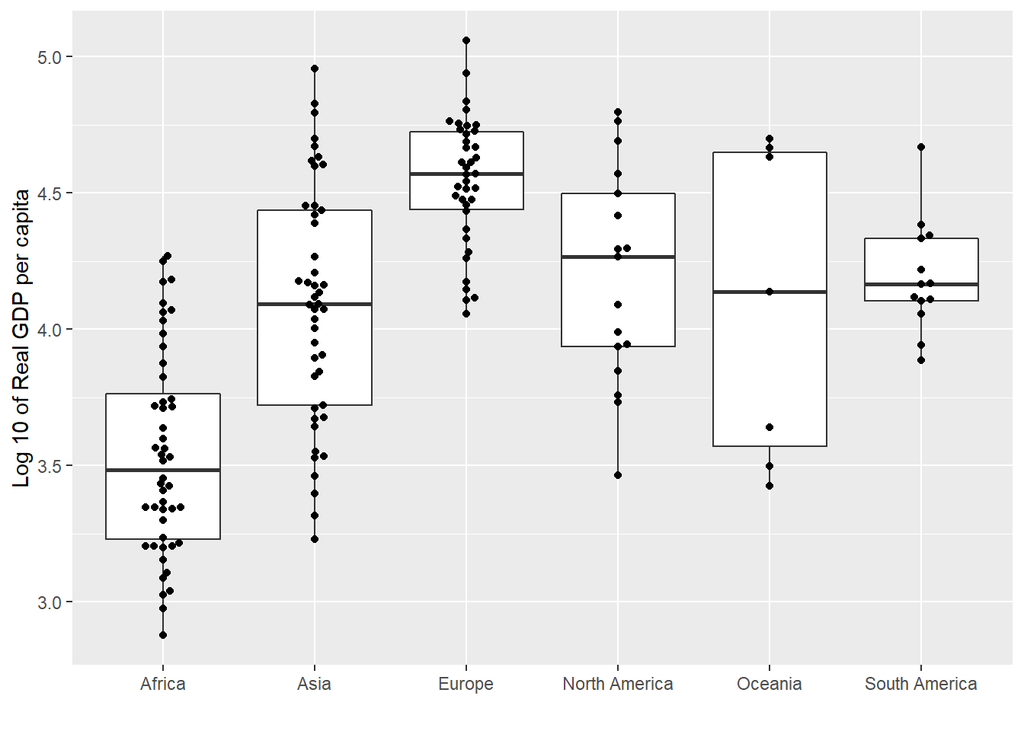

```r
real_gdp_continent <- merge(real_gdp, ref)[,-1]

index_remove <- NULL
for(i in seq(nrow(real_gdp_continent))){
    if(real_gdp_continent[i,2] == "Seven seas (open ocean)"){
        index_remove <- c(index_remove, i)
        }
    }

real_gdp_continent <- as_tibble(real_gdp_continent[-index_remove,])
real_gdp_continent %>% ggplot(aes(continent, log10(value))) + labs(x="", y="Log 10 of Real GDP per capita") + geom_boxplot() + geom_beeswarm()
```

For a better visual, this plot shows the log 10 of real GDP per capita. Africa has the lowest median compared to other continents, though Asia and Oceania have notably large spreads.

```r
head(real_gdp[order(real_gdp[,2], decreasing=TRUE),])
```

```
##          region  value
## 1 liechtenstein 139100
## 2         macau 123965
## 3        monaco 115700
## 4    luxembourg 114482
## 5     singapore  97341
## 6         qatar  90044
```

```r
tail(real_gdp[order(real_gdp[,2], decreasing=TRUE),])
```

```
##                               region value
## 222                       mozambique  1281
## 223                            niger  1225
## 224 democratic republic of the congo  1098
## 225                           malawi  1060
## 226         central african republic   945
## 227                          burundi   752
```

We see that real GDP per capita ranges anywhere from over 100,000 to less than 1000. Africa notably has the top five lowest real GDP per capita.

Scraping unemployment rate data and tidying it to plot on choropleth map.

```r
url_5 <- "https://www.cia.gov/the-world-factbook/field/unemployment-rate/country-comparison"
unemployment_tables <- url_5 %>% read_html() %>% html_nodes("table") %>% html_table()
unemployment <- data.frame(unemployment_tables[[1]][2], unemployment_tables[[1]][3])

colnames(unemployment) <- c("region", "value")
unemployment[,1] <- tolower(unemployment[,1])
unemployment <- unemployment[order(unemployment),]
unemployment <- na.omit(unemployment)

unemployment[15,1] <- "the bahamas"
unemployment[33,1] <- "myanmar"
unemployment[45,1] <- "republic of congo"
unemployment[48,1] <- "ivory coast"
unemployment[53,1] <- "czech republic"
unemployment[64,1] <- "swaziland"
unemployment[106,1] <- "north korea"
unemployment[107,1] <- "south korea"
unemployment[175,1] <- "republic of serbia"
unemployment[192,1] <- "united republic of tanzania"
unemployment[194,1] <- "east timor"
unemployment[207,1] <- "united states of america"
```

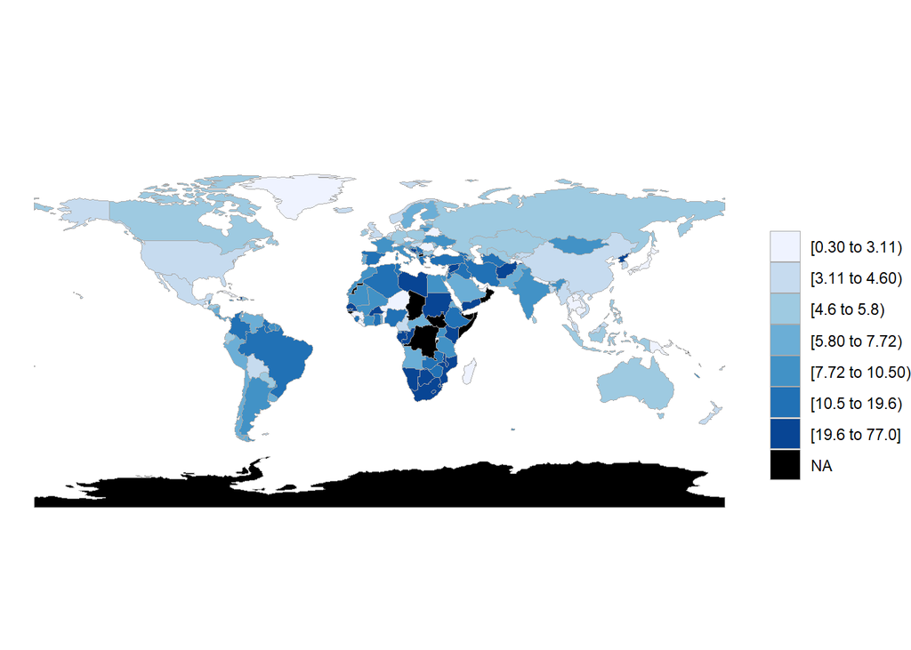

We see that Denmark, Japan, and Madagascar have some of the lowest unemployment rates, while Brazil, North Korea, Afghanistan, and parts of Africa have high unemployment rates.

Using the dataframe ref to tidy the data by continent. The single country beloning to “Seven seas (open ocean)” was removed for visual purposes.

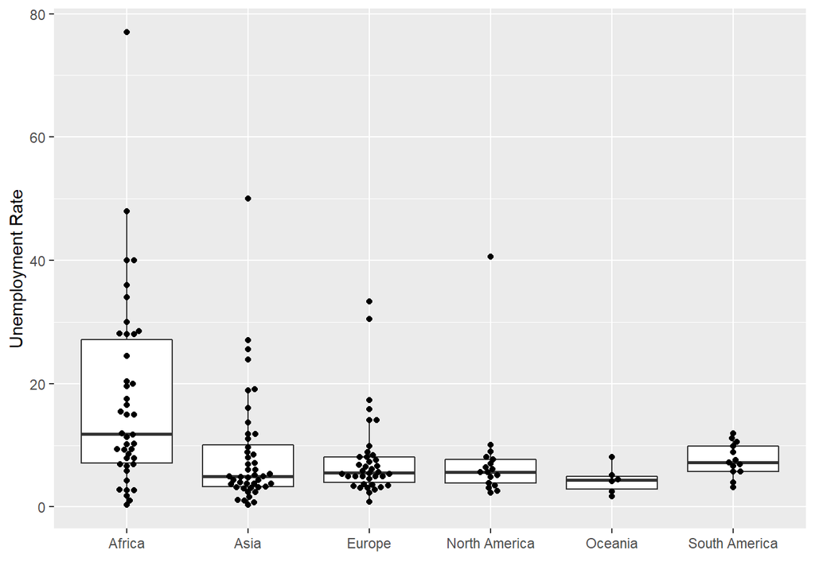

```r
unemployment_continent <- merge(unemployment, ref)[,-1]

index_remove <- NULL
for(i in seq(nrow(unemployment_continent))){
    if(unemployment_continent[i,2] == "Seven seas (open ocean)"){
        index_remove <- c(index_remove, i)
        }
    }

unemployment_continent <- as_tibble(unemployment_continent[-index_remove,])
unemployment_continent %>% ggplot(aes(continent, value)) + labs(x="", y="Unemployment Rate") + geom_boxplot() + geom_beeswarm()
```

We see that Africa has the highest unemployment rates, though it has a very large spread.

```r
head(unemployment[order(unemployment[,2], decreasing=TRUE),])
```

```
##           region value
## 218 burkina faso  77.0
## 217        syria  50.0
## 216      senegal  48.0
## 215        haiti  40.6
## 213     djibouti  40.0
## 214        kenya  40.0
```

```r
tail(unemployment[order(unemployment[,2], decreasing=TRUE),])
```

```
##                    region value
## 6                 belarus  0.80
## 5                   malta  0.78
## 4                    laos  0.70
## 2                cambodia  0.30
## 3                   niger  0.30
## 1 cocos (keeling) islands  0.10
```

Unemployment rates range anywhere from 77% to less than 1% of the population. Even though Africa has some of the highest population growth rates, it also shares both low GDP per capita and high unemployment rates.

Scraping Gini index coefficient data and tidying it to plot on choropleth map.

```r
url_6 <- "https://www.cia.gov/the-world-factbook/field/gini-index-coefficient-distribution-of-family-income/country-comparison"
gini_index_tables <- url_6 %>% read_html() %>% html_nodes("table") %>% html_table()
gini_index <- data.frame(gini_index_tables[[1]][2], gini_index_tables[[1]][3])

colnames(gini_index) <- c("region", "value")
gini_index[,1] <- tolower(gini_index[,1])
gini_index <- gini_index[order(gini_index),]
gini_index <- na.omit(gini_index)

gini_index[21,1] <- "myanmar"
gini_index[33,1] <- "democratic republic of the congo"
gini_index[34,1] <- "republic of congo"
gini_index[36,1] <- "ivory coast"
gini_index[39,1] <- "czech republic"
gini_index[47,1] <- "swaziland"
gini_index[55,1] <- "gambia"
gini_index[64,1] <- "guinea bissau"
gini_index[84,1] <- "south korea"
gini_index[135,1] <- "republic of serbia"
gini_index[151,1] <- "united republic of tanzania"
gini_index[153,1] <- "east timor"
gini_index[164,1] <- "united states of america"
```

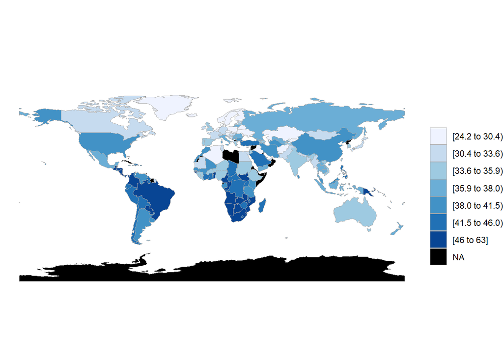

From the plot, we can see that Brazil and the lower parts of Africa share the highest inequality.

Using the dataframe ref to tidy the data by continent. The single country beloning to “Seven seas (open ocean)” was removed for visual purposes.

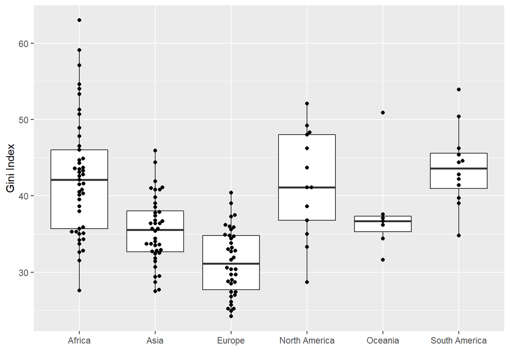

```r
gini_index_continent <- merge(gini_index, ref)[,-1]

index_remove <- NULL
for(i in seq(nrow(gini_index_continent))){
    if(gini_index_continent[i,2] == "Seven seas (open ocean)"){
        index_remove <- c(index_remove, i)
        }
    }

gini_index_continent <- as_tibble(gini_index_continent[-index_remove,])
gini_index_continent %>% ggplot(aes(continent, value)) + labs(x="", y="Gini Index") + geom_boxplot() + geom_beeswarm()
```

```r
head(gini_index[order(gini_index[,2], decreasing=TRUE),])
```

```
##                  region value
## 1          south africa  63.0
## 2               namibia  59.1
## 3                zambia  57.1
## 4 sao tome and principe  56.3
## 5             swaziland  54.6
## 6            mozambique  54.0
```

```r
tail(gini_index[order(gini_index[,2], decreasing=TRUE),])
```

```
##             region value
## 168        belarus  25.2
## 169       slovakia  25.2
## 170 czech republic  24.9
## 171       slovenia  24.2
## 172  faroe islands  22.7
## 173         jersey   0.3
```

Excluding the outlier of Jersey, Gini coefficient ranges anywhere from over 60 to less than 25. The top 5 income inequalities are all found in Africa.

We merge the data into a single data frame to study the relationships between our selected ecnomic features.

```r
pop_density <- data.frame(pop_density[,1], pop_density[,2])
colnames(pop_density) <- c("Country", "Pop_Density")

pop_growth <- data.frame(pop_growth[,1], pop_growth[,2])
colnames(pop_growth) <- c("Country", "Pop_Growth")

life_expectancy <- data.frame(life_expectancy[,1], life_expectancy[,2])
colnames(life_expectancy) <- c("Country", "Life_Exp")

real_gdp <- data.frame(real_gdp[,1], real_gdp[,2])
colnames(real_gdp) <- c("Country", "Real_GDP")

unemployment <- data.frame(unemployment[,1], unemployment[,2])
colnames(unemployment) <- c("Country", "Unemployment")

gini_index <- data.frame(gini_index[,1], gini_index[,2])
colnames(gini_index) <- c("Country", "Gini_Index")

master <- Reduce(function(x,y) merge(x, y, all=TRUE), list(pop_density, pop_growth, life_expectancy, real_gdp, unemployment, gini_index))
master <- master[complete.cases(master),]
head(master)
```

```
##        Country Pop_Density Pop_Growth Life_Exp Real_GDP Unemployment Gini_Index
## 1  afghanistan          60       2.34    53.25     2065        23.90       29.4
## 2      albania         105       0.24    79.23    13965         5.83       33.2
## 3      algeria          18       1.41    77.79    11511        11.70       27.6
## 6       angola          26       3.38    61.71     6670         6.60       51.3
## 9    argentina          17       0.84    78.07    22064         9.84       41.4
## 10     armenia         104      -0.35    75.86    13654        18.90       34.4
```

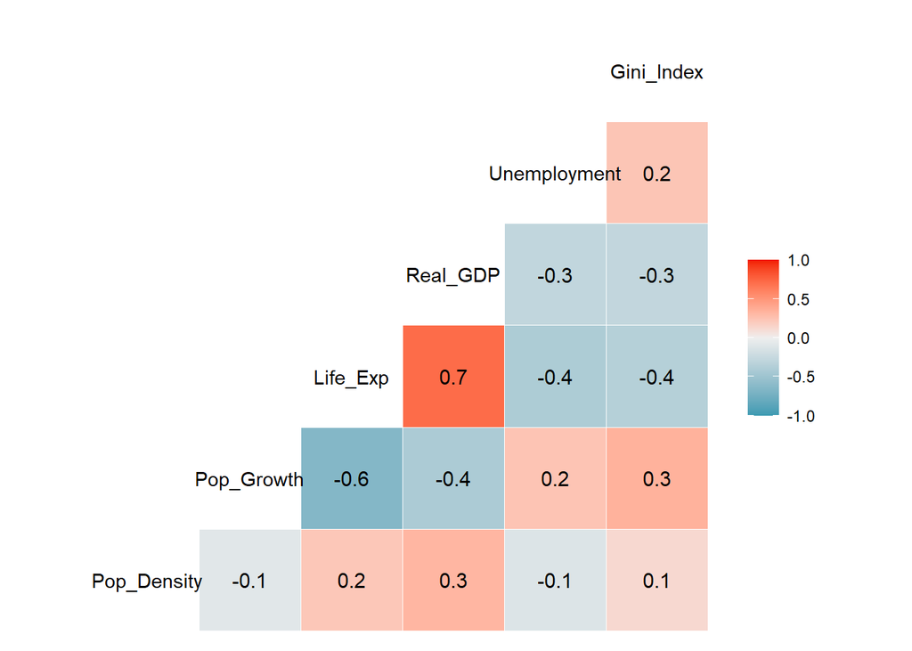

```r
ggcorr(master[,-1], label=TRUE)
```

From the plot, we see that real GDP per capita and life expectancy at birth have a strong postive correlation. On the other hand, life expectancy at birth has a moderate negative correlation with population growth, unemployment rate, and Gini coefficient index. We also gather that real GDP per capita has a moderate negative correlation with population growth.

```r
summary(lm(Life_Exp ~ Pop_Density + Pop_Growth + Real_GDP + Unemployment + Gini_Index, data=master))
```

```
##
## Call:
## lm(formula = Life_Exp ~ Pop_Density + Pop_Growth + Real_GDP +
##     Unemployment + Gini_Index, data = master)
##
## Residuals:
##      Min       1Q   Median       3Q      Max
## -13.3034  -2.5874   0.3759   2.8605   6.9549
##
## Coefficients:
##                Estimate Std. Error t value Pr(>|t|)
## (Intercept)   7.583e+01  1.847e+00  41.051  < 2e-16 ***
## Pop_Density   2.059e-04  3.858e-04   0.534  0.59426
## Pop_Growth   -2.655e+00  3.567e-01  -7.445 7.06e-12 ***
## Real_GDP      1.605e-04  1.768e-05   9.079 5.88e-16 ***
## Unemployment -1.043e-01  3.234e-02  -3.226  0.00154 **
## Gini_Index   -4.892e-02  4.669e-02  -1.048  0.29648
## ---
## Signif. codes:  0 '***' 0.001 '**' 0.01 '*' 0.05 '.' 0.1 ' ' 1
##
## Residual standard error: 3.933 on 150 degrees of freedom
## Multiple R-squared:  0.6915, Adjusted R-squared:  0.6812
## F-statistic: 67.25 on 5 and 150 DF,  p-value: < 2.2e-16
```

Fitting life expectancy at birth as response, we find that population growth, real GDP per capita, and unemployment rate are significant economic predictors. This matches with both the correlation plot and the choropleth map results, since we found Africa to share many extreme traits such as high population growth. Given that life expectancy at birth is impacted by the state of the economy, regions should continue to develop to improve life conditions in the long run.